# Introduction to dendextend

Tal Galili

2019-05-11

**Author**: [Tal Galili](http://www.r-statistics.com/) ( Tal.Galili@gmail.com )

**tl;dr**: the [*dendextend package*](https://cran.r-project.org/package=dendextend) let’s you create figures like this:

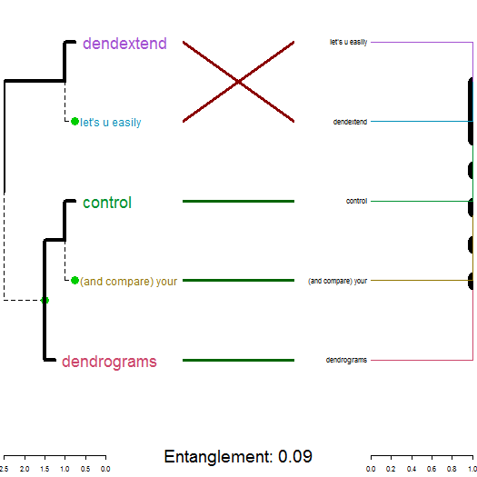

## Introduction

The [*dendextend package*](https://cran.r-project.org/package=dendextend) offers a set of functions for extending dendrogram objects in R, letting you **visualize** and **compare** trees of hierarchical clusterings, you can:

- **Adjust a tree’s graphical parameters** - the color, size, type, etc of its branches, nodes and labels.
- Visually and statistically **compare different dendrograms** to one another.

The goal of this document is to introduce you to the basic functions that dendextend provides, and show how they may be applied. We will make extensive use of “chaining” (explained next).

## Prerequisites

### Acknowledgement

This package was made possible by the the support of my thesis adviser [Yoav Benjamini](http://www.math.tau.ac.il/~ybenja/), as well as code contributions from many R users. They are:

```
#>  [1] "Tal Galili <tal.galili@gmail.com> [aut, cre, cph] (http://www.r-statistics.com)"
#>  [2] "Gavin Simpson [ctb]"
#>  [3] "Gregory Jefferis <jefferis@gmail.com> [ctb] (imported code from his dendroextras package)"
#>  [4] "Marco Gallotta [ctb] (a.k.a: marcog)"
#>  [5] "Johan Renaudie [ctb] (https://github.com/plannapus)"
#>  [6] "R core team [ctb] (Thanks for the Infastructure, and code in the examples)"
#>  [7] "Kurt Hornik [ctb]"
#>  [8] "Uwe Ligges [ctb]"
#>  [9] "Andrej-Nikolai Spiess [ctb]"
#> [10] "Steve Horvath <SHorvath@mednet.ucla.edu> [ctb]"
#> [11] "Peter Langfelder <Peter.Langfelder@gmail.com> [ctb]"
#> [12] "skullkey [ctb]"
#> [13] "Mark Van Der Loo <mark.vanderloo@gmail.com> [ctb] (https://github.com/markvanderloo d3dendrogram)"
#> [14] "Yoav Benjamini [ths]"
```

The **design** of the dendextend package (and this manual!) is heavily inspired by [Hadley Wickham’s](http://had.co.nz/) work. Especially his text on [writing an R package](http://r-pkgs.had.co.nz/), the [devtools package](https://cran.r-project.org/package=devtools), and the dplyr package (specifically the use of chaining, and the [Introduction text to dplyr](https://CRAN.R-project.org/package=dplyr/vignettes/dplyr.html)).

### Chaining

Function calls in dendextend often get a dendrogram and returns a (modified) dendrogram. This doesn’t lead to particularly elegant code if you want to do many operations at once. The same is true even in the first stage of creating a dendrogram.

In order to construct a dendrogram, you will (often) need to go through several steps. You can either do so while keeping the intermediate results:

```r
d1 <- c(1:5) # some data
d2 <- dist(d1)
d3 <- hclust(d2, method = "average")
dend <- as.dendrogram(d3)
```

Or, you can also wrap the function calls inside each other:

```r
dend <- as.dendrogram(hclust(dist(c(1:5)), method = "average"))
```

However, both solutions are not ideal: the first solution includes redundant intermediate objects, while the second is difficult to read (since the order of the operations is from inside to out, while the arguments are a long way away from the function).

To get around this problem, dendextend encourages the use of the `%>%` (“pipe” or “chaining”) operator (imported from the magrittr package). This turns `x %>% f(y)` into `f(x, y)` so you can use it to rewrite (“chain”) multiple operations such that they can be read from left-to-right, top-to-bottom.

For example, the following will be written as it would be explained:

```r
dend <- c(1:5) %>% # take the a vector from 1 to 5
         dist %>% # calculate a distance matrix,
         hclust(method = "average") %>% # on it compute hierarchical clustering using the "average" method,
         as.dendrogram # and lastly, turn that object into a dendrogram.
```

For more details, you may look at:

- [magrittr on CRAN](https://cran.r-project.org/package=magrittr)
- [Introduction to the magrittr package](https://CRAN.R-project.org/package=magrittr/vignettes/magrittr.html)
- [Simpler R coding with pipes > the present and future of the magrittr package](http://www.r-statistics.com/2014/08/simpler-r-coding-with-pipes-the-present-and-future-of-the-magrittr-package/)

### A dendrogram is a nested list of lists with attributes

The first step is working with dendrograms, is to understand that they are just a **nested list of lists with attributes**. Let us explore this for the following (tiny) tree:

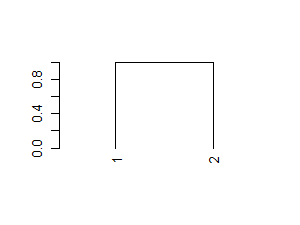

```r
# Create a dend:
dend <- 1:2 %>% dist %>% hclust %>% as.dendrogram
# and plot it:
dend %>% plot
```

And here is its structure (a nested list of lists with attributes):

```r
dend %>% unclass %>% str
```

```
#> List of 2
#>  $ : int 1
#>   ..- attr(*, "label")= int 1
#>   ..- attr(*, "members")= int 1
#>   ..- attr(*, "height")= num 0
#>   ..- attr(*, "leaf")= logi TRUE
#>  $ : int 2
#>   ..- attr(*, "label")= int 2
#>   ..- attr(*, "members")= int 1
#>   ..- attr(*, "height")= num 0
#>   ..- attr(*, "leaf")= logi TRUE
#>  - attr(*, "members")= int 2
#>  - attr(*, "midpoint")= num 0.5
#>  - attr(*, "height")= num 1
```

```r
dend %>% class
```

```
#> [1] "dendrogram"
```

### Installation

To install the stable version on CRAN use:

```r
install.packages('dendextend')
```

To install the GitHub version:

```r
require2 <- function (package, ...) {
   if (!require(package)) install.packages(package); library(package)
}

## require2('installr')
## install.Rtools() # run this if you are using Windows and don't have Rtools installed

# Load devtools:
require2("devtools")
devtools::install_github('talgalili/dendextend')
<!-- require2("Rcpp") -->

# Having colorspace is also useful, since it is used
# In various examples in the vignettes
require2("colorspace")
```

And then you may load the package using:

```r
library(dendextend)
```

## How to explore a dendrogram’s parameters

### Taking a first look at a dendrogram

For the following simple tree:

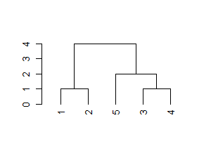

```r
# Create a dend:
dend <- 1:5 %>% dist %>% hclust %>% as.dendrogram
# Plot it:
dend %>% plot
```

Here are some basic parameters we can get:

```r
dend %>% labels # get the labels of the tree
```

```
#> [1] 1 2 5 3 4
```

```r
dend %>% nleaves # get the number of leaves of the tree
```

```
#> [1] 5
```

```r
dend %>% nnodes # get the number of nodes in the tree (including leaves)
```

```
#> [1] 9
```

```r
dend %>% head # A combination of "str" with "head"
```

```
#> --[dendrogram w/ 2 branches and 5 members at h = 4]
#>   |--[dendrogram w/ 2 branches and 2 members at h = 1]
#>   |  |--leaf 1
#>   |  `--leaf 2
#>   `--[dendrogram w/ 2 branches and 3 members at h = 2]
#>      |--leaf 5
#>      `--[dendrogram w/ 2 branches and 2 members at h = 1]
#>         |--leaf 3
#>         `--leaf 4
#> etc...
```

Next let us look at more sophisticated outputs.

### Getting nodes attributes in a depth-first search

When extracting (or inserting) attributes from a dendrogram’s nodes, it is often in a “depth-first search”. [Depth-first search](http://en.wikipedia.org/wiki/Depth-first_search) is when an algorithm for traversing or searching tree or graph data structures. One starts at the root and explores as far as possible along each branch before backtracking.

Here is a plot of a tree, illustrating the order in which you should read the “nodes attributes”:

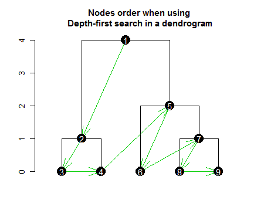

We can get several nodes attributes using `get_nodes_attr` (notice the order corresponds with what is shown in the above figure):

```r
# Create a dend:
dend <- 1:5 %>% dist %>% hclust %>% as.dendrogram
# Get various attributes
dend %>% get_nodes_attr("height") # node's height
```

```
#> [1] 4 1 0 0 2 0 1 0 0
```

```r
dend %>% hang.dendrogram %>% get_nodes_attr("height") # node's height (after raising the leaves)
```

```
#> [1] 4.0 1.0 0.6 0.6 2.0 1.6 1.0 0.6 0.6
```

```r
dend %>% get_nodes_attr("members") # number of members (leaves) under that node
```

```
#> [1] 5 2 1 1 3 1 2 1 1
```

```r
dend %>% get_nodes_attr("members", id = c(2,5)) # number of members for nodes 2 and 5
```

```
#> [1] 2 3
```

```r
dend %>% get_nodes_attr("midpoint") # how much "left" is this node from its left-most child's location
```

```
#> [1] 1.625 0.500    NA    NA 0.750    NA 0.500    NA    NA
```

```r
dend %>% get_nodes_attr("leaf") # is this node a leaf
```

```
#> [1]   NA   NA TRUE TRUE   NA TRUE   NA TRUE TRUE
```

```r
dend %>% get_nodes_attr("label") # what is the label on this node
```

```
#> [1] NA NA  1  2 NA  5 NA  3  4
```

```r
dend %>% get_nodes_attr("nodePar") # empty (for now...)
```

```
#> [1] NA NA NA NA NA NA NA NA NA
```

```r
dend %>% get_nodes_attr("edgePar") # empty (for now...)
```

```
#> [1] NA NA NA NA NA NA NA NA NA
```

A similar function for leaves only is `get_leaves_attr`

## How to change a dendrogram

### The “set” function

The fastest way to start changing parameters with dendextend is by using the `set` function. It is written as: `set(object, what, value)`, and accepts the following parameters:

1. **object**: a dendrogram object,
2. **what**: a character indicating what is the property of the tree that should be set/updated
3. **value**: a vector with the value to set in the tree (the type of the value depends on the “what”). Many times, vectors which are too short are recycled.

The **what** parameter accepts many options, each uses some general function in the background. These options deal with labels, nodes and branches. They are:

- labels - set the labels (using `labels<-.dendrogram`)
- labels_colors - set the labels’ colors (using `color_labels`)
- labels_cex - set the labels’ size (using `assign_values_to_leaves_nodePar`)
- labels_to_character - set the labels’ to be characters
- leaves_pch - set the leaves’ point type (using `assign_values_to_leaves_nodePar`)
- leaves_cex - set the leaves’ point size (using `assign_values_to_leaves_nodePar`)
- leaves_col - set the leaves’ point color (using `assign_values_to_leaves_nodePar`)
- nodes_pch - set the nodes’ point type (using `assign_values_to_nodes_nodePar`)
- nodes_cex - set the nodes’ point size (using `assign_values_to_nodes_nodePar`)
- nodes_col - set the nodes’ point color (using `assign_values_to_nodes_nodePar`)
- hang_leaves - hang the leaves (using `hang.dendrogram`)
- branches_k_color - color the branches (using `color_branches`)
- branches_col - set the color of branches (using `assign_values_to_branches_edgePar`)
- branches_lwd - set the line width of branches (using `assign_values_to_branches_edgePar`)
- branches_lty - set the line type of branches (using `assign_values_to_branches_edgePar`)
- by_labels_branches_col - set the color of branches with specific labels (using `branches_attr_by_labels`)
- by_labels_branches_lwd - set the line width of branches with specific labels (using `branches_attr_by_labels`)
- by_labels_branches_lty - set the line type of branches with specific labels (using `branches_attr_by_labels`)
- clear_branches - clear branches’ attributes (using `remove_branches_edgePar`)
- clear_leaves - clear leaves’ attributes (using `remove_branches_edgePar`)

### Two simple trees to play with

For illustration purposes, we will create several small tree, and demonstrate these functions on them.

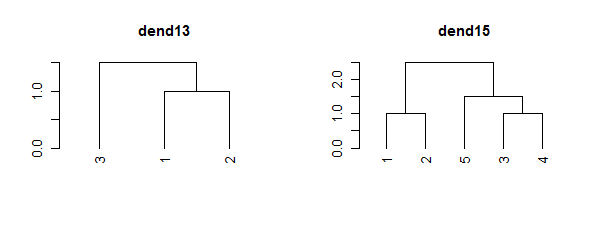

```r
dend13 <- c(1:3) %>% # take some data
         dist %>% # calculate a distance matrix,
         hclust(method = "average") %>% # on it compute hierarchical clustering using the "average" method,
         as.dendrogram # and lastly, turn that object into a dendrogram.
# same, but for 5 leaves:
dend15 <- c(1:5) %>% dist %>% hclust(method = "average") %>% as.dendrogram

par(mfrow = c(1,2))
dend13 %>% plot(main="dend13")
dend15 %>% plot(main="dend15")
# we could have also used plot(dend)
```

### Setting a dendrogram’s labels

We can get a vector with the tree’s labels:

```r
# get the labels:
dend15 %>% labels
```

```
#> [1] 1 2 5 3 4
```

```r
# this is just like labels(dend)
```

Notice how the tree’s labels are not 1 to 5 by order, since the tree happened to place them in a different order. We can change the names of the labels:

```r
# change the labels, and then print them:
dend15 %>% set("labels", c(111:115)) %>% labels
```

```
#> [1] 111 112 113 114 115
```

```r
# could also be done using:
# labels(dend) <- c(111:115)
```

We can change the type of labels to be characters. Not doing so may be a source of various bugs and problems in many functions.

```r
dend15 %>% labels
```

```
#> [1] 1 2 5 3 4
```

```r
dend15 %>% set("labels_to_char") %>% labels
```

```
#> [1] "1" "2" "5" "3" "4"
```

We may also change their color and size:

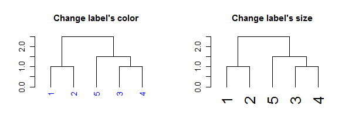

```r
par(mfrow = c(1,2))
dend15 %>% set("labels_col", "blue") %>% plot(main = "Change label's color") # change color
dend15 %>% set("labels_cex", 2) %>% plot(main = "Change label's size") # change color
```

The function recycles, from left to right, the vector of values we give it. We can use this to create more complex patterns:

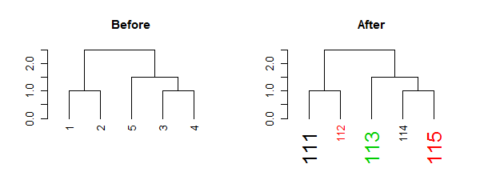

```r
# Produce a more complex dendrogram:
dend15_2 <- dend15 %>%
   set("labels", c(111:115)) %>%    # change labels
   set("labels_col", c(1,2,3)) %>%  # change color
   set("labels_cex", c(2,1))        # change size

par(mfrow = c(1,2))
dend15 %>% plot(main = "Before")
dend15_2 %>% plot(main = "After")
```

Notice how these “labels parameters” are nested within the nodePar attribute:

```r
# looking at only the left-most node of the "after tree":
dend15_2[[1]][[1]] %>% unclass %>% str
```

```
#>  int 1
#>  - attr(*, "label")= int 111
#>  - attr(*, "members")= int 1
#>  - attr(*, "height")= num 0
#>  - attr(*, "leaf")= logi TRUE
#>  - attr(*, "nodePar")=List of 3
#>   ..$ lab.col: num 1
#>   ..$ pch    : logi NA
#>   ..$ lab.cex: num 2
```

```r
# looking at only the nodePar attributes in this sub-tree:
dend15_2[[1]][[1]] %>% get_nodes_attr("nodePar")
```

```
#>         [,1]
#> lab.col 1
#> pch     NA
#> lab.cex 2
```

When it comes to color, we can also set the parameter “k”, which will cut the tree into k clusters, and assign a different color to each label (based on its cluster):

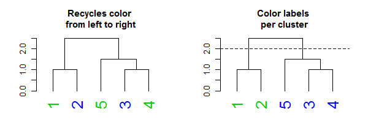

```r
par(mfrow = c(1,2))
dend15 %>% set("labels_cex", 2) %>% set("labels_col", value = c(3,4)) %>%
   plot(main = "Recycles color \nfrom left to right")
dend15 %>% set("labels_cex", 2) %>% set("labels_col", value = c(3,4), k=2) %>%
   plot(main = "Color labels \nper cluster")
abline(h = 2, lty = 2)
```

### Setting a dendrogram’s nodes/leaves (points)

Each node in a tree can be represented and controlled using the `assign_values_to_nodes_nodePar`, and for the special case of the nodes of leaves, the `assign_values_to_leaves_nodePar` function is more appropriate (and faster) to use. We can control the following properties: pch (point type), cex (point size), and col (point color). For example:

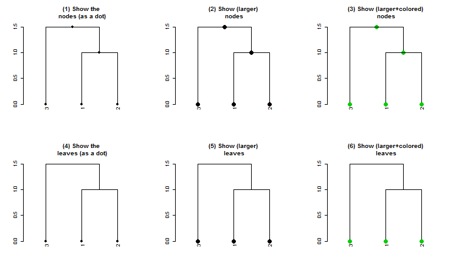

```r
par(mfrow = c(2,3))
dend13 %>% set("nodes_pch", 19) %>% plot(main = "(1) Show the\n nodes (as a dot)") #1
dend13 %>% set("nodes_pch", 19) %>% set("nodes_cex", 2) %>%
   plot(main = "(2) Show (larger)\n nodes") #2
dend13 %>% set("nodes_pch", 19) %>% set("nodes_cex", 2) %>% set("nodes_col", 3) %>%
   plot(main = "(3) Show (larger+colored)\n nodes") #3

dend13 %>% set("leaves_pch", 19) %>% plot(main = "(4) Show the\n leaves (as a dot)") #4
dend13 %>% set("leaves_pch", 19) %>% set("leaves_cex", 2) %>%
   plot(main = "(5) Show (larger)\n leaves") #5
dend13 %>% set("leaves_pch", 19) %>% set("leaves_cex", 2) %>% set("leaves_col", 3) %>%
   plot(main = "(6) Show (larger+colored)\n leaves") #6
```

And with recycling we can produce more complex outputs:

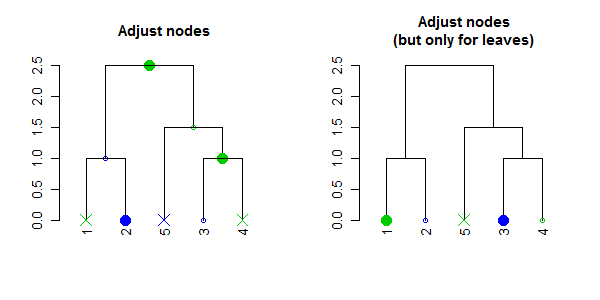

```r
par(mfrow = c(1,2))
dend15 %>% set("nodes_pch", c(19,1,4)) %>% set("nodes_cex", c(2,1,2)) %>% set("nodes_col", c(3,4)) %>%
   plot(main = "Adjust nodes")
dend15 %>% set("leaves_pch", c(19,1,4)) %>% set("leaves_cex", c(2,1,2)) %>% set("leaves_col", c(3,4)) %>%
   plot(main = "Adjust nodes\n(but only for leaves)")
```

Notice how recycling works in a depth-first order (which is just left to right, when we only adjust the leaves). Here are the node’s parameters after adjustment:

```r
dend15 %>% set("nodes_pch", c(19,1,4)) %>%
   set("nodes_cex", c(2,1,2)) %>% set("nodes_col", c(3,4)) %>% get_nodes_attr("nodePar")
```

```
#>     [,1] [,2] [,3] [,4] [,5] [,6] [,7] [,8] [,9]
#> pch 19   1    4    19   1    4    19   1    4
#> cex 2    1    2    2    1    2    2    1    2
#> col 3    4    3    4    3    4    3    4    3
```

We can also change the height of of the leaves by using the `hang.dendrogram` function:

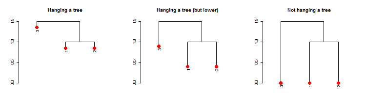

```r
par(mfrow = c(1,3))
dend13 %>% set("leaves_pch", 19) %>% set("leaves_cex", 2) %>% set("leaves_col", 2) %>% # adjust the leaves
   hang.dendrogram %>% # hang the leaves
   plot(main = "Hanging a tree")
dend13 %>% set("leaves_pch", 19) %>% set("leaves_cex", 2) %>% set("leaves_col", 2) %>% # adjust the leaves
   hang.dendrogram(hang_height = .6) %>% # hang the leaves (at some height)
   plot(main = "Hanging a tree (but lower)")
dend13 %>% set("leaves_pch", 19) %>% set("leaves_cex", 2) %>% set("leaves_col", 2) %>% # adjust the leaves
   hang.dendrogram %>% # hang the leaves
   hang.dendrogram(hang = -1) %>% # un-hanging the leaves
   plot(main = "Not hanging a tree")
```

An example of what this function does to the leaves heights:

```r
dend13 %>% get_leaves_attr("height")
```

```
#> [1] 0 0 0
```

```r
dend13 %>% hang.dendrogram %>% get_leaves_attr("height")
```

```
#> [1] 1.35 0.85 0.85
```

We can also control the general heights of nodes using `raise.dendrogram`:

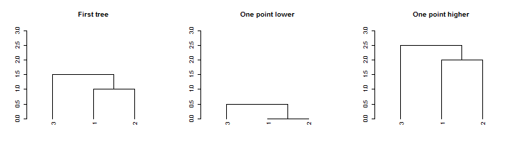

```r
par(mfrow = c(1,3))
dend13 %>% plot(main = "First tree", ylim = c(0,3))
dend13 %>%
   raise.dendrogram (-1) %>%
   plot(main = "One point lower", ylim = c(0,3))
dend13 %>%
   raise.dendrogram (1) %>%
   plot(main = "One point higher", ylim = c(0,3))
```

If you wish to make the branches under the root have the same height, you can use the `flatten.dendrogram` function.

### Setting a dendrogram’s branches

#### Adjusting all branches

Similar to adjusting nodes, we can also control line width (lwd), line type (lty), and color (col) for branches:

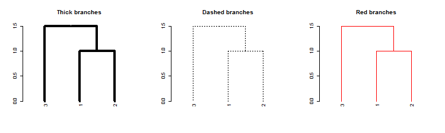

```r
par(mfrow = c(1,3))
dend13 %>% set("branches_lwd", 4) %>% plot(main = "Thick branches")
dend13 %>% set("branches_lty", 3) %>% plot(main = "Dashed branches")
dend13 %>% set("branches_col", 2) %>% plot(main = "Red branches")
```

We may also use recycling to create more complex patterns:

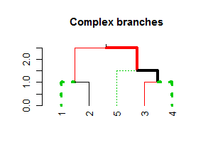

```r
# Produce a more complex dendrogram:
dend15 %>%
   set("branches_lwd", c(4,1)) %>%
   set("branches_lty", c(1,1,3)) %>%
   set("branches_col", c(1,2,3)) %>%
   plot(main = "Complex branches", edge.root = TRUE)
```

Notice how the first branch (the root) is considered when going through and creating the tree, but it is **ignored** in the actual plotting (this is actually a “missing feature” in `plot.dendrogram`).

#### Coloring branches based on clustering

We may also control the colors of the branches based on using clustering:

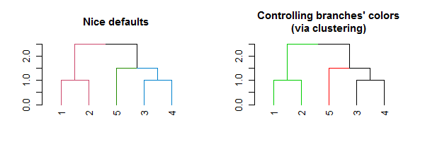

```r
par(mfrow = c(1,2))
dend15 %>% set("branches_k_color", k = 3) %>% plot(main = "Nice defaults")
dend15 %>% set("branches_k_color", value = 3:1, k = 3) %>%
   plot(main = "Controlling branches' colors\n(via clustering)")
```

```r
# This is like using the `color_branches` function
```

#### Adjusting branches based on labels

The most powerful way to control branches is through the `branches_attr_by_labels` function (with variations through the `set` function). The function allows you to change col/lwd/lty of branches if they match some “labels condition”. Follow carefully:

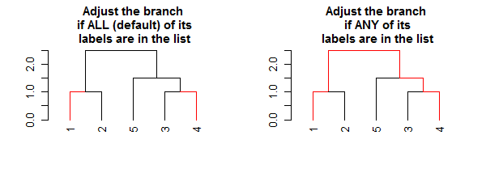

```r
par(mfrow = c(1,2))
dend15 %>% set("by_labels_branches_col", value = c(1,4)) %>%
   plot(main = "Adjust the branch\n if ALL (default) of its\n labels are in the list")
dend15 %>% set("by_labels_branches_col", value = c(1,4), type = "any") %>%
   plot(main = "Adjust the branch\n if ANY of its\n labels are in the list")
```

We can use this to change the size/type/color of the branches:

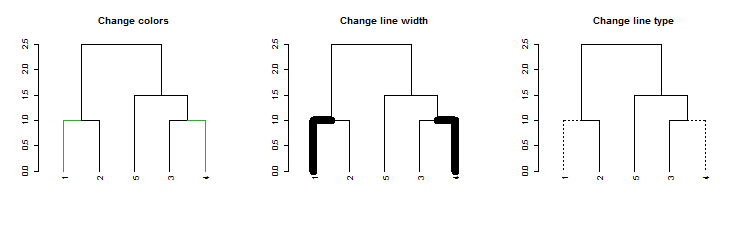

```r
# Using "Inf" in "TF_values" means to let the parameters stay as they are.
par(mfrow = c(1,3))
dend15 %>% set("by_labels_branches_col", value = c(1,4), TF_values = c(3,Inf)) %>%
   plot(main = "Change colors")
dend15 %>% set("by_labels_branches_lwd", value = c(1,4), TF_values = c(8,1)) %>%
   plot(main = "Change line width")
dend15 %>% set("by_labels_branches_lty", value = c(1,4), TF_values = c(3,Inf)) %>%
   plot(main = "Change line type")
```

#### Highlighting branches’ different heights using line width and color

The `highlight_branches` function helps to more easily see the topological structure of a tree, by adjusting branches appearence (color and line width) based on their height in the tree. For example:

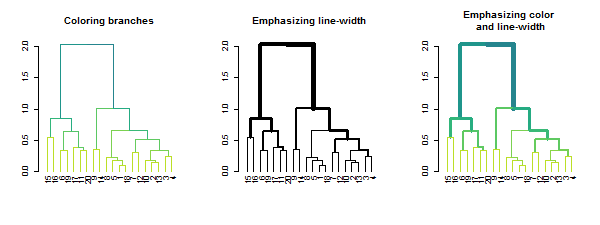

```r
dat <- iris[1:20,-5]
hca <- hclust(dist(dat))
hca2 <- hclust(dist(dat), method = "single")
dend <- as.dendrogram(hca)
dend2 <- as.dendrogram(hca2)

par(mfrow = c(1,3))
dend %>% highlight_branches_col %>% plot(main = "Coloring branches")
dend %>% highlight_branches_lwd %>% plot(main = "Emphasizing line-width")
dend %>% highlight_branches %>% plot(main = "Emphasizing color\n and line-width")
```

```r
library(viridis)
```

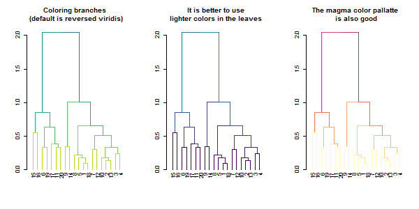

```r
par(mfrow = c(1,3))
dend %>% highlight_branches_col %>% plot(main = "Coloring branches \n(default is reversed viridis)")
dend %>% highlight_branches_col(viridis(100)) %>% plot(main = "It is better to use\nlighter colors in the leaves")
dend %>% highlight_branches_col(rev(magma(1000))) %>% plot(main = "The magma color pallatte\n is also good")
```

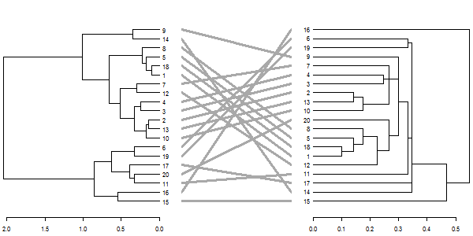

```r
dl <- dendlist(dend, dend2)
tanglegram(dl, sort = TRUE, common_subtrees_color_lines = FALSE, highlight_distinct_edges  = FALSE, highlight_branches_lwd = FALSE)
```

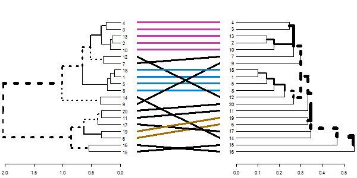

```r
tanglegram(dl)
```

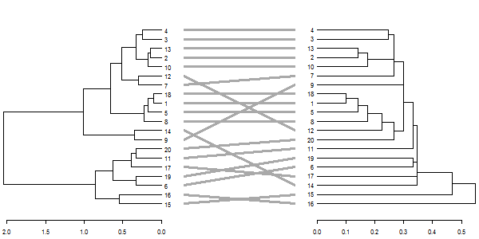

```r
tanglegram(dl, fast = TRUE)
```

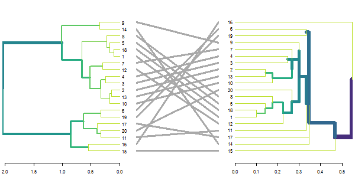

```r
dl <- dendlist(highlight_branches(dend), highlight_branches(dend2))
tanglegram(dl, sort = TRUE, common_subtrees_color_lines = FALSE, highlight_distinct_edges  = FALSE)
```

```r
# dend %>% set("highlight_branches_col") %>% plot

dl <- dendlist(dend, dend2) %>% set("highlight_branches_col")
tanglegram(dl, sort = TRUE, common_subtrees_color_lines = FALSE, highlight_distinct_edges  = FALSE)
```

[output not shown]

### Changing a dendrogram’s structure

#### Rotation

A dendrogram is an object which can be rotated on its hinges without changing its topology. Rotating a dendrogram in base R can be done using the `reorder` function. The problem with this function is that it is not very intuitive. For this reason the `rotate` function was written. It has two main arguments: the “object” (a dendrogram), and the “order” we wish to rotate it by. The “order” parameter can be either a numeric vector, used in a similar way we would order a simple character vector. Or, the order parameter can also be a character vector of the labels of the tree, given in the new desired order of the tree. It is also worth noting that some order are impossible to achieve for a given tree’s topology. In such cases, the function will do its “best” to get as close as possible to the requested rotation.

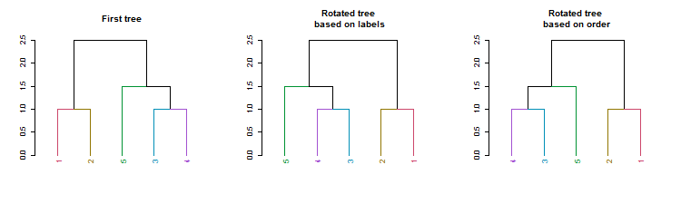

```r
par(mfrow = c(1,3))
dend15 %>%
   set("labels_colors") %>%
   set("branches_k_color") %>%
   plot(main = "First tree")
dend15 %>%
   set("labels_colors") %>%
   set("branches_k_color") %>%
   rotate(as.character(5:1)) %>% #rotate to match labels new order
   plot(main = "Rotated tree\n based on labels")
dend15 %>%
   set("labels_colors") %>%
   set("branches_k_color") %>%
   rotate(5:1) %>% # the fifth label to go first is "4"
   plot(main = "Rotated tree\n based on order")
```

A new convenience S3 function for `sort` (`sort.dendrogram`) was added:

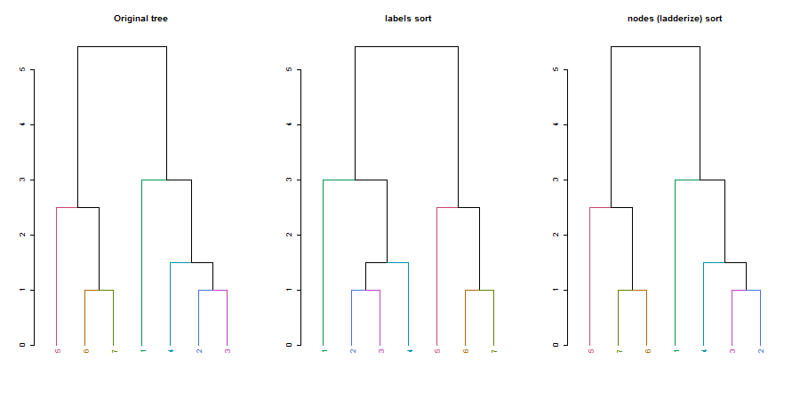

```r
dend110 <- c(1, 3:5, 7,9,10) %>% dist %>% hclust(method = "average") %>%
   as.dendrogram %>% color_labels %>% color_branches

par(mfrow = c(1,3))
dend110 %>% plot(main = "Original tree")
dend110 %>% sort %>% plot(main = "labels sort")
dend110 %>% sort(type = "nodes") %>% plot(main = "nodes (ladderize) sort")
```

#### Unbranching

We can unbranch a tree:

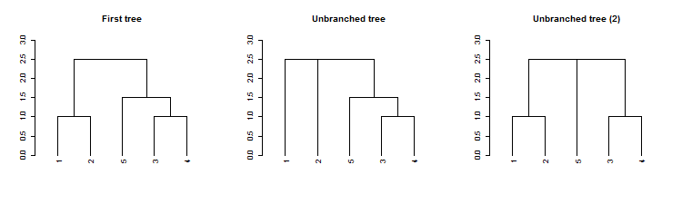

```r
par(mfrow = c(1,3))
dend15 %>% plot(main = "First tree", ylim = c(0,3))
dend15 %>%
   unbranch %>%
   plot(main = "Unbranched tree", ylim = c(0,3))
dend15 %>%
   unbranch(2) %>%
   plot(main = "Unbranched tree (2)", ylim = c(0,3))
```

#### Pruning

We can prune a tree based on the labels:

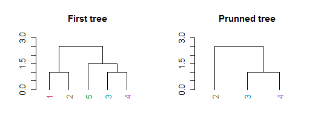

```r
par(mfrow = c(1,2))
dend15 %>% set("labels_colors") %>%
   plot(main = "First tree", ylim = c(0,3))
dend15 %>% set("labels_colors") %>%
   prune(c("1","5")) %>%
   plot(main = "Prunned tree", ylim = c(0,3))
```

For pruning two trees to have matching labels, we can use the `intersect_trees` function:

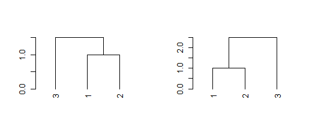

```r
par(mfrow = c(1,2))
dend_intersected <- intersect_trees(dend13, dend15)
dend_intersected[[1]] %>% plot
dend_intersected[[2]] %>% plot
```

#### Collapse branches

We can collapse branches under a tolerance level using the `collapse_branch` function:

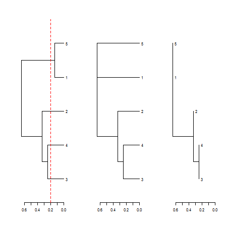

```r
# ladderize is like sort(..., type = "node")
dend <- iris[1:5,-5] %>% dist %>% hclust %>% as.dendrogram
par(mfrow = c(1,3))
dend %>% ladderize %>%  plot(horiz = TRUE); abline(v = .2, col = 2, lty = 2)
dend %>% collapse_branch(tol = 0.2) %>% ladderize %>% plot(horiz = TRUE)
dend %>% collapse_branch(tol = 0.2) %>% ladderize %>% hang.dendrogram(hang = 0) %>% plot(horiz = TRUE)
```

### Adding extra bars and rectangles

#### Adding colored rectangles

Earlier we have seen how to highlight clusters in a dendrogram by coloring branches. We can also draw rectangles around the branches of a dendrogram in order to highlight the corresponding clusters. First the dendrogram is cut at a certain level, then a rectangle is drawn around selected branches. This is done using the `rect.dendrogram`, which is modeled based on the `rect.hclust` function. One advantage of `rect.dendrogram` over `rect.hclust`, is that it also works on horizontally plotted trees:

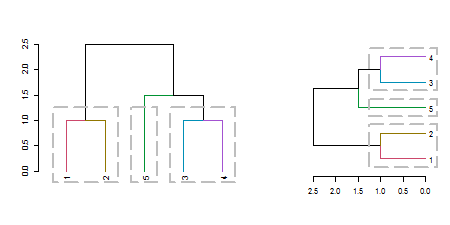

```r
layout(t(c(1,1,1,2,2)))

dend15 %>% set("branches_k_color") %>% plot
dend15 %>% rect.dendrogram(k=3,
                           border = 8, lty = 5, lwd = 2)

dend15 %>% set("branches_k_color") %>% plot(horiz = TRUE)
dend15 %>% rect.dendrogram(k=3, horiz = TRUE,
                           border = 8, lty = 5, lwd = 2)
```

#### Adding colored bars

Adding colored bars to a dendrogram may be useful to show clusters or some outside categorization of the items. For example:

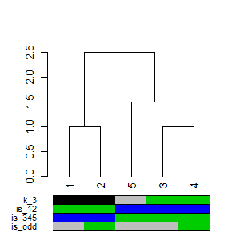

```r
is_odd <- ifelse(labels(dend15) %% 2, 2,3)
is_345 <- ifelse(labels(dend15) > 2, 3,4)
is_12 <- ifelse(labels(dend15) <= 2, 3,4)
k_3 <- cutree(dend15,k = 3, order_clusters_as_data = FALSE)
# The FALSE above makes sure we get the clusters in the order of the
# dendrogram, and not in that of the original data. It is like:
# cutree(dend15, k = 3)[order.dendrogram(dend15)]
the_bars <- cbind(is_odd, is_345, is_12, k_3)
the_bars[the_bars==2] <- 8

dend15 %>% plot
colored_bars(colors = the_bars, dend = dend15, sort_by_labels_order = FALSE)
```

```r
# we use sort_by_labels_order = FALSE since "the_bars" were set based on the
# labels order. The more common use case is when the bars are based on a second variable
# from the same data.frame as dend was created from. Thus, the default
# sort_by_labels_order = TRUE would make more sense.
```

Another example, based on mtcars (in which the default of `sort_by_labels_order = TRUE` makes sense):

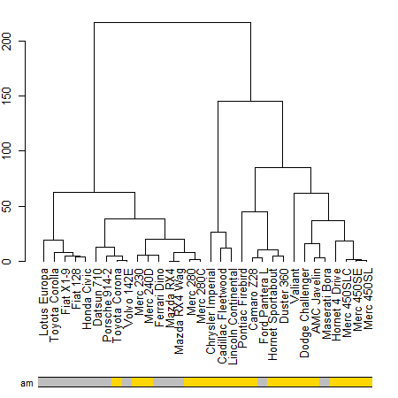

```r
dend_mtcars <- mtcars[, c("mpg", "disp")] %>% dist %>% hclust(method = "average") %>% as.dendrogram

par(mar = c(10,2,1,1))
plot(dend_mtcars)
the_bars <- ifelse(mtcars$am, "grey", "gold")
colored_bars(colors = the_bars, dend = dend_mtcars, rowLabels = "am")
```